# Maps, Coordinate Reference Systems and Visualising Geographic Data with mapmisc

## 5 Additional code

### 5.1 European fertility

URL’s for web sites where data are obtained:

```r
nutsUrl <- "http://ec.europa.eu/eurostat/cache/GISCO/geodatafiles/NUTS_2010_60M_SH.zip"
nutsFile <- basename(nutsUrl)
```

Download and read in boundary file:

```r
if (!file.exists(nutsFile)) {
    download.file(nutsUrl, nutsFile, method = "curl")
}
unzip(nutsFile)
nutsShp <- grep("RG_60M_2010.shp$", unzip(nutsFile, list = TRUE)$Name, value = TRUE)
euroNuts <- shapefile(nutsShp)
```

```r
fertUrl <- file.path("http://ec.europa.eu/eurostat/estat-navtree-portlet-prod",
    "BulkDownloadListing?sort=1&file=data%2Fdemo_r_frate2.tsv.gz")
fertFileGz <- "demo_r_frate2.tsv.gz"
fertFile <- gsub(".gz$", "", fertFileGz)
if (!file.exists(fertFileGz)) {
    download.file(fertUrl, fertFileGz, method = "curl")
}
R.utils::gunzip(fertFileGz, overwrite = file.exists(fertFile), remove = FALSE)
euroDat <- read.table(fertFile, header = TRUE, stringsAsFactors = FALSE, sep = "\t",
    na.strings = ": ")
euroDat <- euroDat[grep("^TOTAL", euroDat[, 1]), ]
euroDat$timegeo <- gsub("^TOTAL,", "", euroDat[, 1])
```

Merge the fertility and polygon data. Warning messages that not all rows of the fertility table can be matched to polygons can be ignored.

```r
euroF <- sp::merge(euroNuts, euroDat, all.x = FALSE, by.x = "NUTS_ID",
    by.y = "timegeo")
```

Exclude some of the outlying parts of the EU:

```r
euroF <- raster::crop(euroF, extent(-25, 180, 33, 90))
```

### 5.2 Canada

Transform the Great Circle:

```r
gcircleT <- mapply(spTransform, CRSobj = crsList, MoreArgs = list(x = gcircle))
```

Obtain background maps:

```r
mapT <- mapply(openmap, crs = crsList, MoreArgs = list(path = "nrcan", x = cities,
    buffer = 3))
```

Create maps:

```r
for (D in names(crsList)) {
    map.new(citiesT[[D]], buffer = c(200 * 1000, 1)[1 + isLonLat(citiesT[[D]])])
    plotRGB(mapT[[D]], add = TRUE)
    rgdal::llgridlines(citiesT[[D]], col = "orange")
    points(gcircleT[[D]], cex = 0.1, col = "blue")
    points(citiesT[[D]], col = "red", pch = "+", cex = 1.5)
    text(citiesT[[D]], labels = citiesT[[D]]$name, col = "red", pos = cities$pos,
        offset = 0.6, cex = 1.2)
    scaleBar(citiesT[[D]], "topleft", seg.len = 4, pt.cex = 0)
}
```

## 6 Additional tables and figures

Table 4: Colour palettes from *RColorBrewer*, with `col` showing the character string to provide `colourScale` or `brewer.pal` and `max` giving the maximum number of colours for each palette.

| col | max | palette |
| --- | --- | --- |
| BrBG | 11 | ■■■■■■■■■■■■■■■■■■■■■■■■■■■■■■■■■■■■■■■■■■■■ |
| PiYG | 11 | ■■■■■■■■■■■■■■■■■■■■■■■■■■■■■■■■■■■■■■■■■■■■ |
| PRGn | 11 | ■■■■■■■■■■■■■■■■■■■■■■■■■■■■■■■■■■■■■■■■■■■■ |
| PuOr | 11 | ■■■■■■■■■■■■■■■■■■■■■■■■■■■■■■■■■■■■■■■■■■■■ |
| RdBu | 11 | ■■■■■■■■■■■■■■■■■■■■■■■■■■■■■■■■■■■■■■■■■■■■ |
| RdGy | 11 | ■■■■■■■■■■■■■■■■■■■■■■■■■■■■■■■■■■■■■■■■■■■■ |
| RdYlBu | 11 | ■■■■■■■■■■■■■■■■■■■■■■■■■■■■■■■■■■■■■■■■■■■■ |
| RdYlGn | 11 | ■■■■■■■■■■■■■■■■■■■■■■■■■■■■■■■■■■■■■■■■■■■■ |
| Spectral | 11 | ■■■■■■■■■■■■■■■■■■■■■■■■■■■■■■■■■■■■■■■■■■■■ |
| Accent | 8 | ■■■■■■■■■■■■■■■■■■■■■■■■■■■■■■■■ |
| Dark2 | 8 | ■■■■■■■■■■■■■■■■■■■■■■■■■■■■■■■■ |
| Paired | 12 | ■■■■■■■■■■■■■■■■■■■■■■■■■■■■■■■■■■■■■■■■■■■■■■■■ |
| Pastel1 | 9 | ■■■■■■■■■■■■■■■■■■■■■■■■■■■■■■■■■■■■ |
| Pastel2 | 8 | ■■■■■■■■■■■■■■■■■■■■■■■■■■■■■■■■ |
| Set1 | 9 | ■■■■■■■■■■■■■■■■■■■■■■■■■■■■■■■■■■■■ |
| Set2 | 8 | ■■■■■■■■■■■■■■■■■■■■■■■■■■■■■■■■ |
| Set3 | 12 | ■■■■■■■■■■■■■■■■■■■■■■■■■■■■■■■■■■■■■■■■■■■■■■■■ |
| Blues | 9 | ■■■■■■■■■■■■■■■■■■■■■■■■■■■■■■■■■■■■ |
| BuGn | 9 | ■■■■■■■■■■■■■■■■■■■■■■■■■■■■■■■■■■■■ |
| BuPu | 9 | ■■■■■■■■■■■■■■■■■■■■■■■■■■■■■■■■■■■■ |
| GnBu | 9 | ■■■■■■■■■■■■■■■■■■■■■■■■■■■■■■■■■■■■ |
| Greens | 9 | ■■■■■■■■■■■■■■■■■■■■■■■■■■■■■■■■■■■■ |
| Greys | 9 | ■■■■■■■■■■■■■■■■■■■■■■■■■■■■■■■■■■■■ |
| Oranges | 9 | ■■■■■■■■■■■■■■■■■■■■■■■■■■■■■■■■■■■■ |
| OrRd | 9 | ■■■■■■■■■■■■■■■■■■■■■■■■■■■■■■■■■■■■ |
| PuBu | 9 | ■■■■■■■■■■■■■■■■■■■■■■■■■■■■■■■■■■■■ |
| PuBuGn | 9 | ■■■■■■■■■■■■■■■■■■■■■■■■■■■■■■■■■■■■ |
| PuRd | 9 | ■■■■■■■■■■■■■■■■■■■■■■■■■■■■■■■■■■■■ |
| Purples | 9 | ■■■■■■■■■■■■■■■■■■■■■■■■■■■■■■■■■■■■ |
| RdPu | 9 | ■■■■■■■■■■■■■■■■■■■■■■■■■■■■■■■■■■■■ |
| Reds | 9 | ■■■■■■■■■■■■■■■■■■■■■■■■■■■■■■■■■■■■ |
| YlGn | 9 | ■■■■■■■■■■■■■■■■■■■■■■■■■■■■■■■■■■■■ |
| YlGnBu | 9 | ■■■■■■■■■■■■■■■■■■■■■■■■■■■■■■■■■■■■ |
| YlOrBr | 9 | ■■■■■■■■■■■■■■■■■■■■■■■■■■■■■■■■■■■■ |
| YlOrRd | 9 | ■■■■■■■■■■■■■■■■■■■■■■■■■■■■■■■■■■■■ |

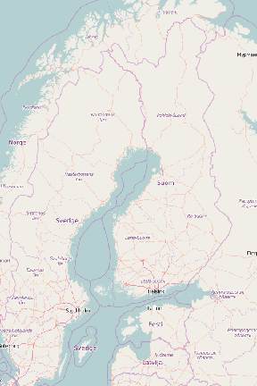

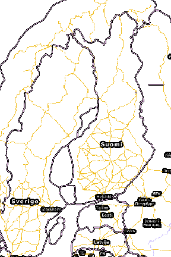

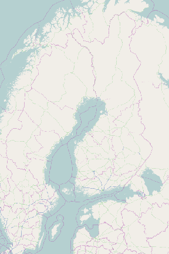

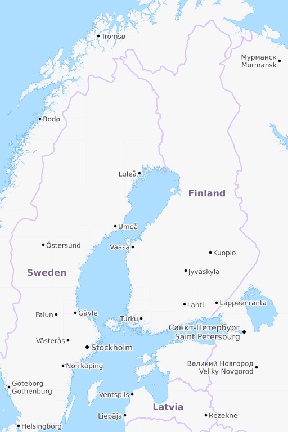

1. osm, © [OpenStreetMap](http://openstreetmap.org/copyright).
2. osm-semitransparent, © [OpenStreetMap](http://openstreetmap.org/copyright).
3. osm-no-labels, © [OpenStreetMap](http://openstreetmap.org/copyright).
4. osm-transport, © [OpenStreetMap](http://openstreetmap.org/copyright).

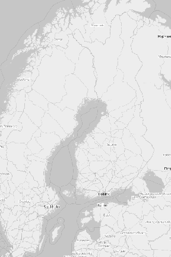

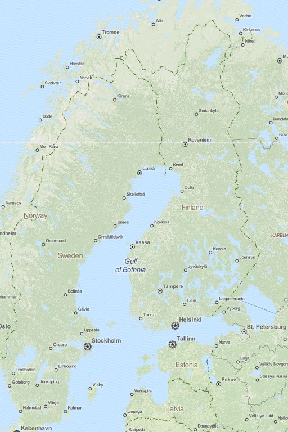

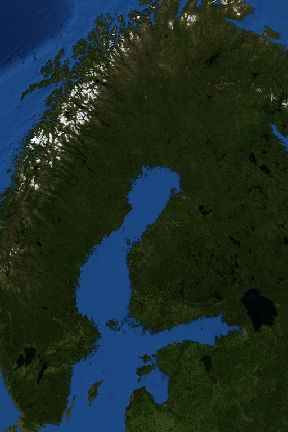

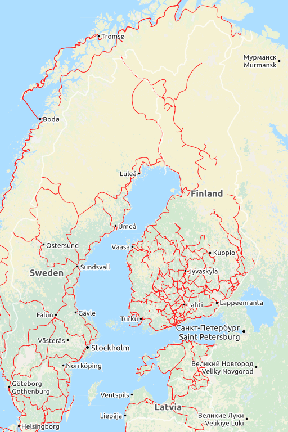

5. bw-mapnik, © [OpenStreetMap](http://openstreetmap.org/copyright).
6. mapquest. Tiles courtesy of [MapQuest](http://www.mapquest.com).
7. mapquest-sat. Tiles courtesy of [MapQuest](http://www.mapquest.com).
8. osm-cyclemap, © [OpenStreetMap](http://openstreetmap.org/copyright).

[figure not shown]

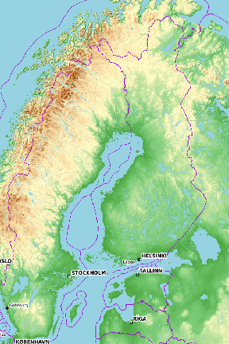

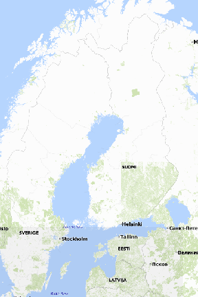

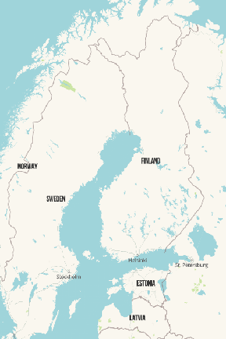

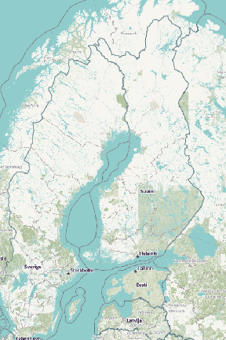

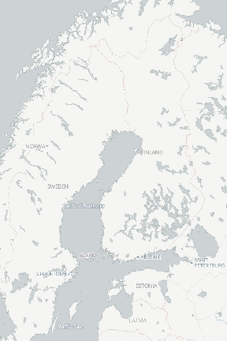

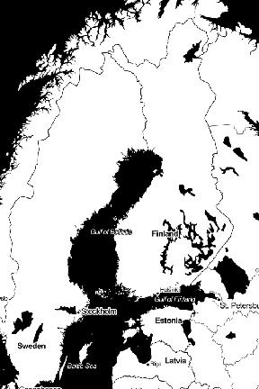

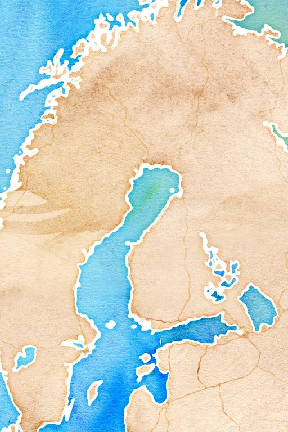

13. humanitarian, © [OpenStreetMap](http://openstreetmap.org/copyright).
14. cartodb, © [CartoDB](http://cartodb.com).
15. stamen-toner, © [Stamen Design](http://stamen.com).
16. stamen-watercolor, © [Stamen Design](http://stamen.com).

Figure 11: Selected `openmap` tile sets.

### 6.1 CRAN packages used

sp, raster, mapmisc, rgdal, RColorBrewer, classInt, rgeos, geosphere, dismo, maptools, R.utils, geostatsp, knitr, ggplot2, leaflet

### 6.2 CRAN Task Views implied by cited packages

Agriculture, ChemPhys, DynamicVisualizations, NetworkAnalysis, Phylogenetics, ReproducibleResearch, Spatial, SpatioTemporal, TeachingStatistics

H. Bengtsson. *R.utils: Various programming utilities.* 2016. URL https://CRAN.R-project.org/package=R.utils. R package version 2.3.0.

R. Bivand. *classInt: Choose univariate class intervals.* 2015. URL https://CRAN.R-project.org/package=classInt. R package version 0.1-23.

R. S. Bivand, E. Pebesma and V. Gomez-Rubio. *Applied spatial data analysis with R.* 2nd ed New York: Springer, 2013. URL http://www.asdar-book.org/.

R. Bivand, T. Keitt and B. Rowlingson. *Rgdal: Bindings for the geospatial data abstraction library.* 2016. URL https://CRAN.R-project.org/package=rgdal. R package version 1.1-8.

R. Bivand and N. Lewin-Koh. *Maptools: Tools for reading and handling spatial objects.* 2016. URL https://CRAN.R-project.org/package=maptools. R package version 0.8-39.

R. Bivand and C. Rundel. *Rgeos: Interface to geometry engine – open source (GEOS).* 2016. URL https://CRAN.R-project.org/package=rgeos. R package version 0.3-19.

P. Brown. *Mapmisc: Utilities for producing maps.* 2016. URL https://CRAN.R-project.org/package=mapmisc. R package version 1.5.0.

P. E. Brown. Model-based geostatistics the easy way. *Journal of Statistical Software*, 63(12): 1–24, 2015. URL http://www.jstatsoft.org/v63/i12/.

J. Cheng and Y. Xie. *Leaflet: Create interactive web maps with the JavaScript “leaflet” library.* 2016. URL https://CRAN.R-project.org/package=leaflet. R package version 1.0.1.

R. J. Hijmans. *Geosphere: Spherical trigonometry.* 2015a. URL https://CRAN.R-project.org/package=geosphere. R package version 1.5-1.

R. J. Hijmans. *Raster: Geographic data analysis and modeling.* 2015b. URL https://CRAN.R-project.org/package=raster. R package version 2.5-2.

R. J. Hijmans, S. Phillips, J. Leathwick and J. Elith. *Dismo: Species distribution modeling.* 2016. URL https://CRAN.R-project.org/package=dismo. R package version 1.0-15.

G. F. Jenks and F. C. Caspall. Error on choroplethic maps: Definition, measurement, reduction. *The Annals of the Association of American Geographers*, 61(2): 217–244, 1971.

R. Munroe. Map projections. 2011. URL http://xkcd.com/977. [Online; accessed 11-March-2015].

E. Neuwirth. *RColorBrewer: ColorBrewer palettes.* 2014. URL https://CRAN.R-project.org/package=RColorBrewer. R package version 1.1-2.

E. J. Pebesma and R. S. Bivand. Classes and methods for spatial data in R. *R News*, 5(2): 9–13, 2005. URL http://CRAN.R-project.org/doc/Rnews/.

J. P. Snyder. Map projections – A working manual. 1395. Washington, DC: US Geologic Survey; US Government Printing Office. 1987. URL http://pubs.usgs.gov/pp/1395/report.pdf.

H. Wickham. *ggplot2: Elegant Graphics for Data Analysis.* Springer-Verlag New York, 2009. URL http://ggplot2.org.

Wikipedia. *Great-circle distance – Wikipedia, The Free Encyclopedia, natexlaba.* [Online; accessed 3-November-], 2015a. URL https://en.wikipedia.org/w/index.php?title=Great-circle_distance&oldid=688488703.

Wikipedia. *Mollweide projection – Wikipedia, The Free Encyclopedia, natexlabb.* [Online; accessed 25-November-], 2015b. URL https://en.wikipedia.org/w/index.php?title=Mollweide_projection&oldid=689173007.

Wikipedia. *Web Mercator – Wikipedia, The Free Encyclopedia, .* [Online; accessed 19-May-], 2016. URL https://en.wikipedia.org/w/index.php?title=Web_Mercator&oldid=714750105.

Y. Xie. *Dynamic documents with R and knitr.* 2nd ed Boca Raton, Florida: Chapman; Hall/CRC, 2015. URL http://yihui.name/knitr/.

[^1]: The Web Mercator, which originated with Google Maps, is in fact slightly different from the Spherical Mercator assigned to map images by *mapmisc*. Maps in a Web Mercator projection are visually identical to a Spherical Mercator, but the Mercator $x$-$y$ coordinates are hidden and users are shown coordinates which have been converted long-lat (EPSG 4326). The group managing the EPSG codes initially refused to assign a code to the Web Mercator, reportedly saying: “We will not devalue the EPSG dataset by including such inappropriate geodesy and cartography” (Wikipedia 2016). The Web Mercator was later assigned EPSG code 3857.
[^2]: Many Canadians residing outside Toronto prefer the somewhat less affectionate nickname of “Hogtown”, claiming Torontonians are arrogant and collectively self-centred.
[^3]: Readers should be aware that Grise Fiord resulted from a government-run resettlement program in the 1950’s, and involved the deception and neglect of the indigenous people who were relocated to the hamlet.